# Experiment 4: summa with time pressure

### Before Exclusions

**Number of participants tested:**

```
## [1] 1200
```

**Participants in each condition:**

```
##
## all_QUD any_QUD  no_QUD
##     400     400     400
```

### Exclusions

**Non-unique participants (remove all attempts):**

```
## integer(0)
```

**Participants whose native language is not english:**

```
##    workerid  language
## 1        17        29
## 2        37 Cantonese
## 3        82 Hungarian
## 4        84
## 5       119   swahili
## 6       151   Spanish
## 7       220   Chinese
## 8       245   Spanish
## 9       390      Urdu
## 10      402  Filipino
## 11      420
## 12      430   Spanish
## 13      461   Russian
## 14      494   finnish
```

[output cut: 23 more lines]

**Participants who got at least three practice trials wrong:**

```
##
##  3  4
## 58 35
```

**Participants who got the audio check wrong more than one once:**

```
##
## 187 601 696 816 953
##   1   1   1   1   1
```

**Participants who got the second comprehension question wrong more than twice:**

```
## # A tibble: 15 x 2
## # Groups:   workerid [15]
##    workerid     n
##       <int> <int>
##  1       59     3
##  2      185     4
##  3      213     3
##  4      401     4
##  5      432     7
##  6      457     3
##  7      604     3
##  8      659     3
##  9      668     3
## 10      694     5
## 11      714     3
## 12      741     3
## 13      753     3
## 14      755     4
## 15      791     3
```

**Participants with accuracy of lower than 85% on non-critical trials with “some”,“none”,“all” and numbers below 6:**

```
##     workerid gaveRightAnswer  n answerNm  accuracy
## 1         15               1 14       38 36.842105
## 2         19               1 21       39 53.846154
## 3         24               1 38       46 82.608696
## 4         29               1  6       48 12.500000
## 5         31               1 35       46 76.086957
## 6         43               1 24       48 50.000000
## 7         47               1 19       46 41.304348
## 8         51               1 21       43 48.837209
## 9         61               1 26       48 54.166667
## 10        73               1  2       48  4.166667
## 11        77               1 37       48 77.083333
## 12        85               1 28       47 59.574468
## 13        87               1 19       41 46.341463
## 14        88               1 21       45 46.666667
```

[output cut: 186 more lines]

#### Additional Exclusions

**Participants who gave more than 5 very slow (logRT>20) responses:**

```
## # A tibble: 0 x 3
## # Groups:   workerid [0]
## # … with 3 variables: workerid <int>, slowResponse <lgl>, n <int>
```

**Responses that are faster than the onset of the quantifier (rawRT<600):**

```
## [1] 411
```

**Responses that are very slow (logRT>20):**

```
## [1] 47
```

## After Exclusions

**Number of participants:**

```
## [1] 850
```

**Participants left in each condition:**

```
##
## all_QUD any_QUD  no_QUD
##     281     256     313
```

## General

**Expected number of yes and no answers:**

```
##
##    No   Yes
## 22299 26447
```

**Accuracy**

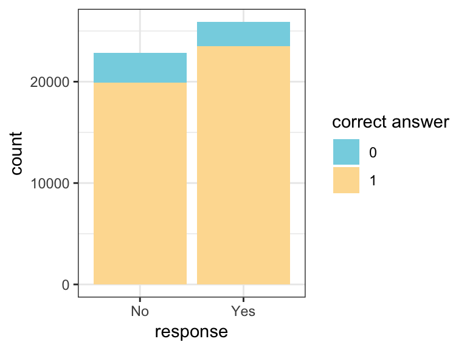

**Accuracy and trial order**

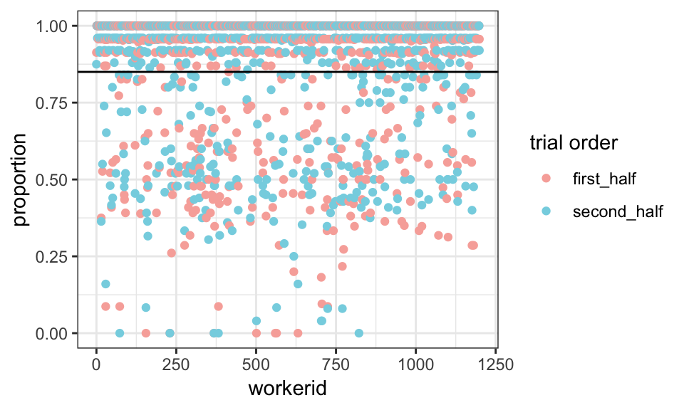

**Distribution of RT and logRT**

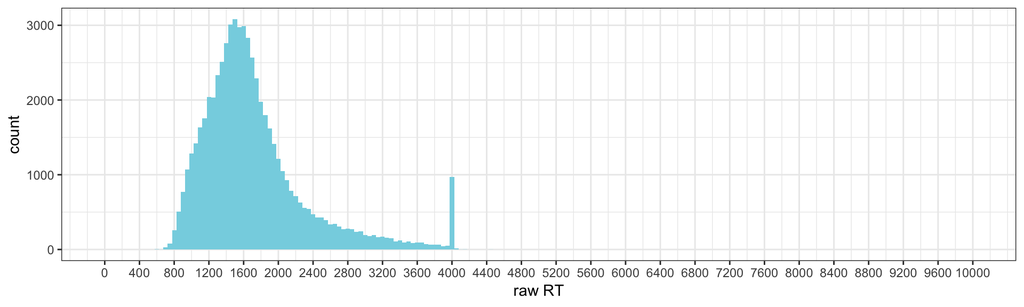

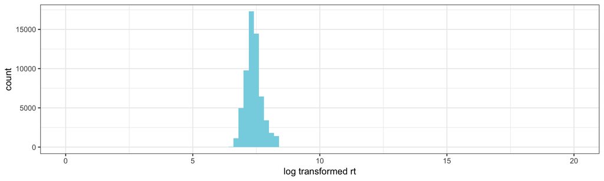

15 fastest responses (raw RT)

```
##  [1] 603 605 622 624 645 679 687 688 693 695 699 700 700 700 700
```

15 slowest responses (raw RT)

```
##  [1] 4029 4031 4031 4031 4032 4034 4042 4045 4047 4054 4064 4077 4137 4152
## [15] 4447
```

### Non-critical Trials

**Response type:**

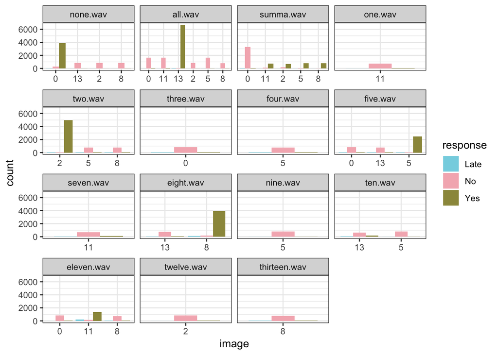

**Response time:**

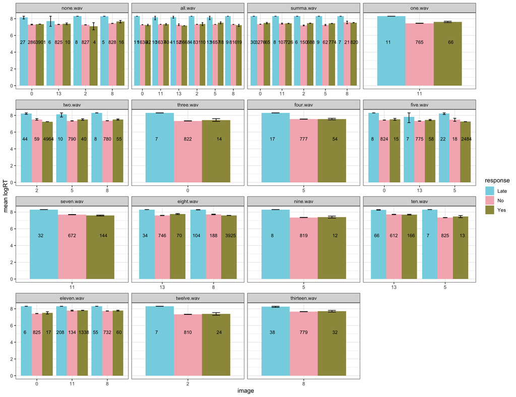

### Critical Trials

**Total number of critical trials (8 per participant):**

```
## [1] 6740
```

**Total number of critical trials with late responses removed:**

```
## [1] 6644
```

#### Response Type

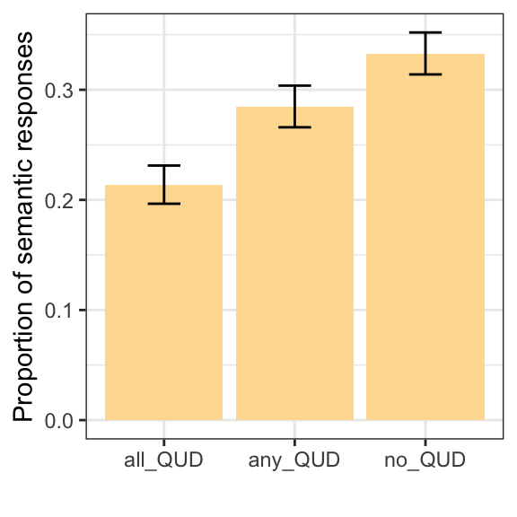

**Distribution of participants over number of semantic responses**

```
##
##             0   1   2   3   4   5   6   7   8
##   all_QUD 161  42   9   7  12   7   9  13  20
##   any_QUD 128  39  13   9   3   6   6  14  38
##   no_QUD  153  36  12   9   6   2  10  32  51
```

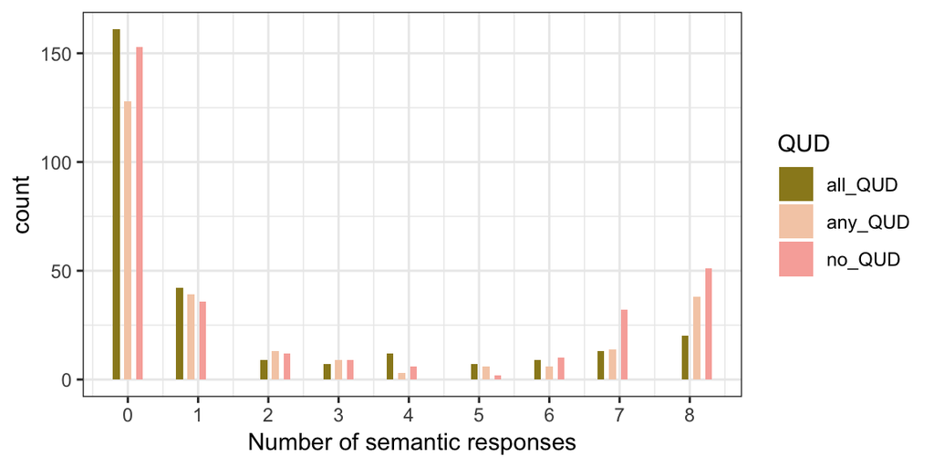

**Response type and trial order**

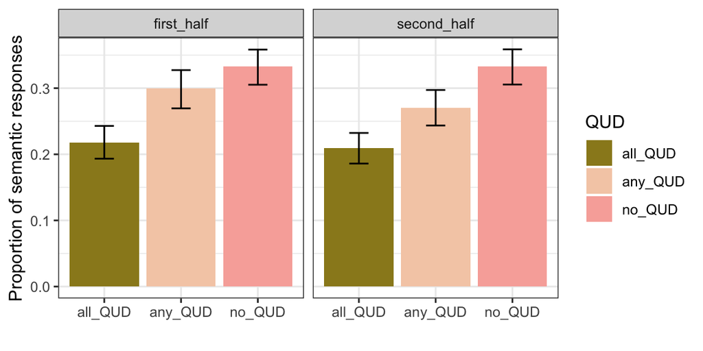

**Age distribution of participants**

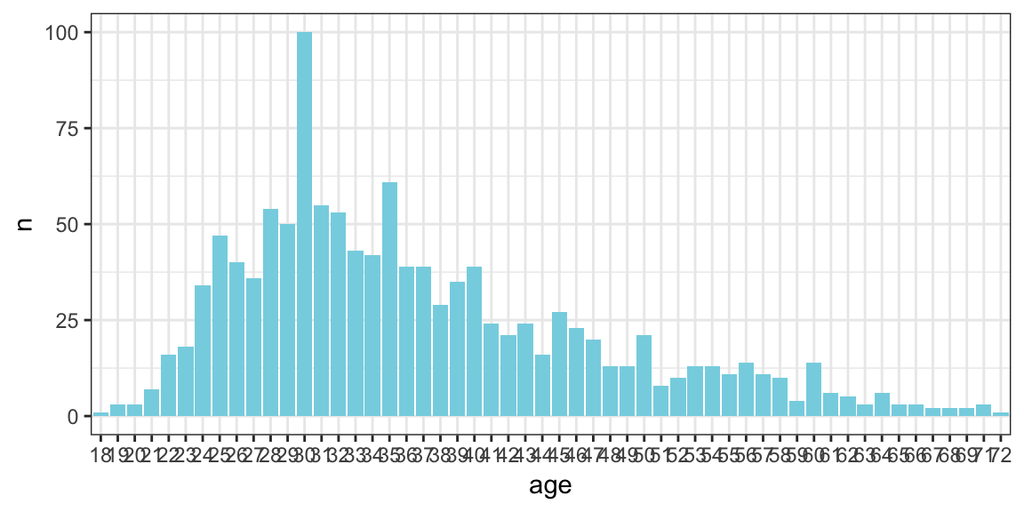

**Response type and age**

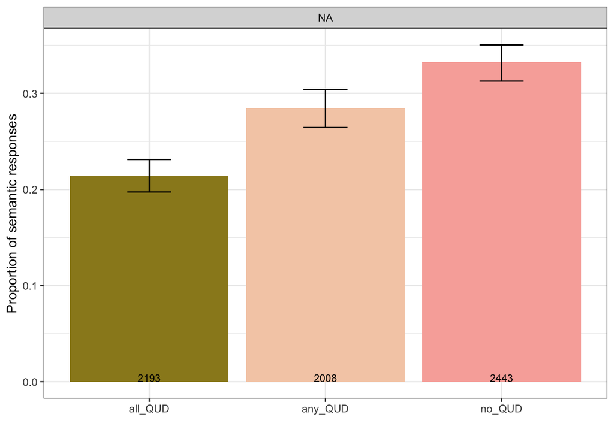

#### Response Time

**Distribution of response times in critical trials**

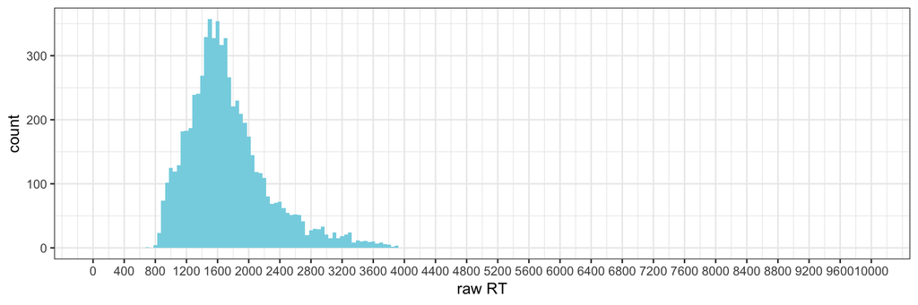

**Response time and QUD**

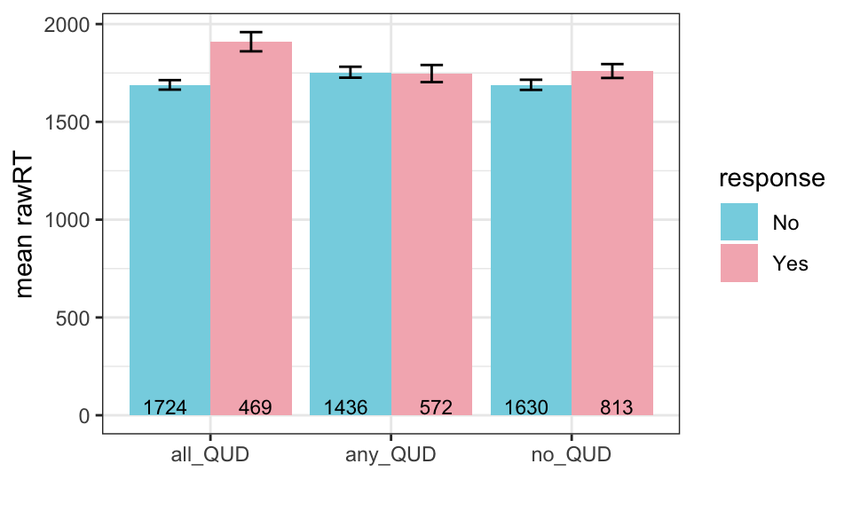

**Response time, trial order and QUD**

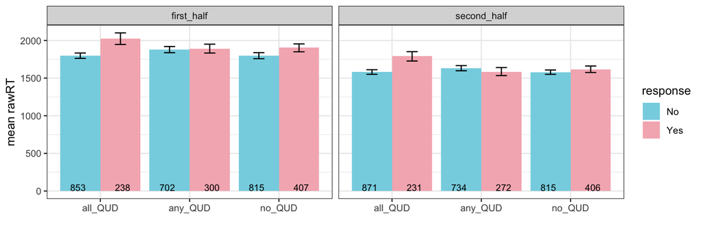

**Response time, responder type and QUD**

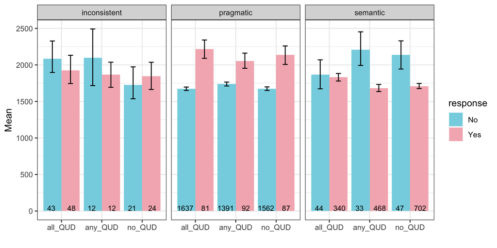

**Response time, age and QUD**

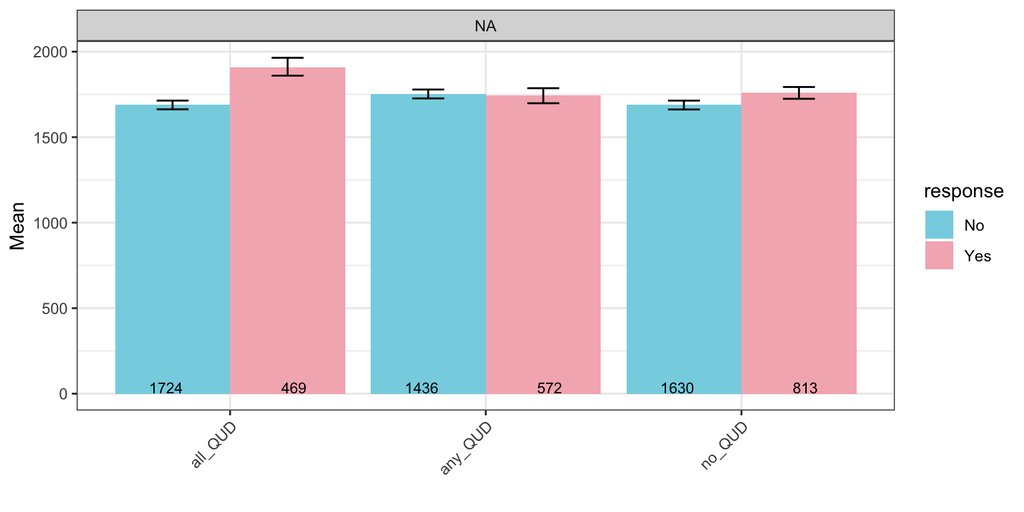

**Response time, age, responder type and QUD**

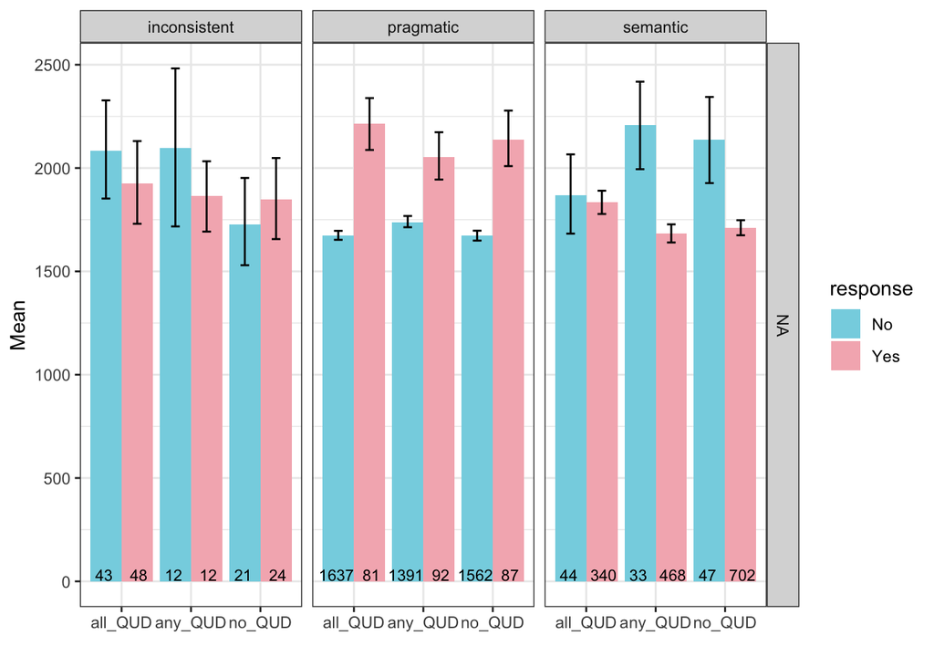